# Exploring the Bay Wheels (Lyft) Bike Dataset for August 2021

#### Let's examine the number of rides by rider type in August 2021 (member v. casual).

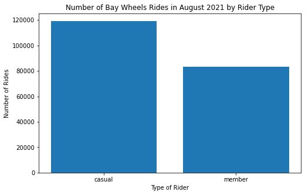

```python
#plotting the types of riders on a bar chart.

fig = plt.figure(figsize=[8,5])
plt.bar(x = df_clean["rider_type"].value_counts().keys(), height = df_clean["rider_type"].value_counts() )
plt.title('Number of Bay Wheels Rides in August 2021 by Rider Type')
plt.xlabel('Type of Rider')
plt.ylabel('Number of Rides')
plt.show()
```

#### Let's look at the number of rides by day in August 2021.

```python
#group data by start day
test = df_clean["started_at"].groupby(df_clean["started_at"].dt.floor('d')).size().reset_index(name='count')
```

```python
#convert date to day of the week and day of month format
test["date"] = test["started_at"].dt.strftime('%a %d')
```

#### This line chart shows that in August 2021, the number of rides in a given day for all rider and bike types ranged from just under 5,500 to nearly 8,000. Overall ridership tended to dip on Mondays and peak on Saturdays.

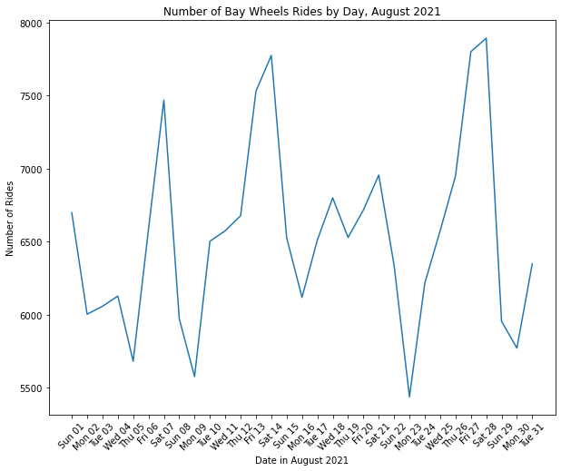

```python
plt.rcParams["figure.figsize"] = [10,8]
ax=sns.lineplot(x="date", y="count", data=test)
plt.title("Number of Bay Wheels Rides by Day, August 2021")
plt.xlabel('Date in August 2021')
plt.ylabel('Number of Rides')
plt.xticks(test["date"], rotation=45);
```

#### Let's look at the start hour (based on a 24-hour day) for rides in August 2021.

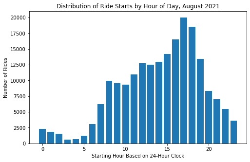

```python
#Examine the hour of day that rides started in August 2021
plt.figure(figsize=[8,5])
plt.bar(x = df_clean["start_datehour"].value_counts().keys(), height = df_clean["start_datehour"].value_counts() )
plt.title("Distribution of Ride Starts by Hour of Day, August 2021")
plt.xlabel('Starting Hour Based on 24-Hour Clock')
plt.ylabel('Number of Rides')
plt.show()
```

#### Rides (measured by start time) peak at 17:00 hour, or 5 p.m.

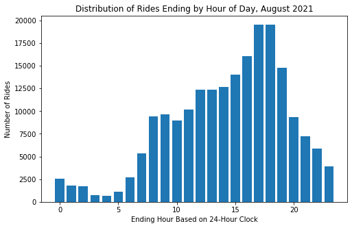

```python
#Examine the hour of day that rides ended in August 2021
plt.figure(figsize=[8,5])
plt.bar(x = df_clean["end_datehour"].value_counts().keys(), height = df_clean["end_datehour"].value_counts() )
plt.title("Distribution of Rides Ending by Hour of Day, August 2021")
plt.xlabel('Ending Hour Based on 24-Hour Clock')
plt.ylabel('Number of Rides')
plt.show()
```

#### Rides (measured by end time) peak at around 5 p.m. and 6 p.m.

#### Let's examine the days of the week that rides started in August 2021.

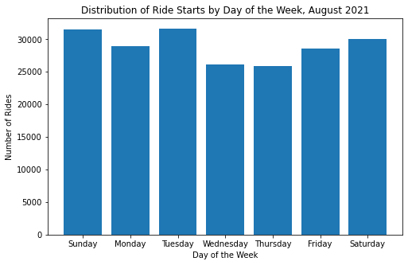

```python
plt.figure(figsize=[8,5])
plt.bar(x = df_clean["start_dayofweek"].value_counts().sort_index().keys(),  height = df_clean["start_dayofweek"].value_counts().sort_index())
plt.title("Distribution of Ride Starts by Day of the Week, August 2021")
plt.xlabel('Day of the Week')
plt.ylabel('Number of Rides')
plt.show()
```

#### Interestingly, more rides in August 2021 started on Sunday, Tuesday and Saturday.

#### Let's examine the days of the week that rides ended in August 2021.

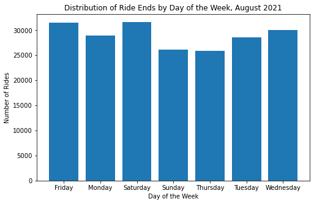

```python
#Look at what days of the week rides end at
plt.figure(figsize=[8,5])
plt.bar(x = df_clean["end_dayofweek"].value_counts().sort_index().keys(), height = df_clean["start_dayofweek"].value_counts().sort_index() )
plt.title("Distribution of Ride Ends by Day of the Week, August 2021")
plt.xlabel('Day of the Week')
plt.ylabel('Number of Rides')
plt.show();
```

#### Let's look at the top 10 stations for starting and ending rides.

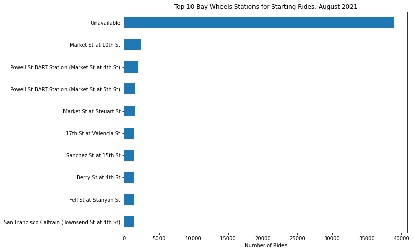

```python
top_stations = df_clean['start_station_name'].value_counts()[:10].sort_values()
top_stations.plot(kind='barh')
plt.title('Top 10 Bay Wheels Stations for Starting Rides, August 2021')
plt.xlabel('Number of Rides');
```

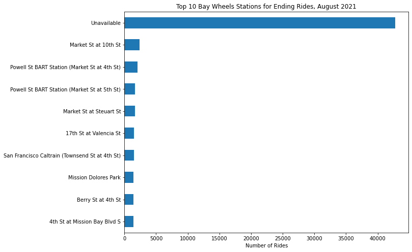

```python
top_stations = df_clean["end_station_name"].value_counts()[:10].sort_values()
top_stations.plot(kind='barh')
plt.title('Top 10 Bay Wheels Stations for Ending Rides, August 2021')
plt.xlabel('Number of Rides');
```

#### The most common start and end station is "Unavailable," as in the ride did not begin or end at a Bay Wheels station.

#### Let's explore the dist_in_km variable, which is the rough distance in kilometers (km) between the starting and ending latitude and longitude pairs.

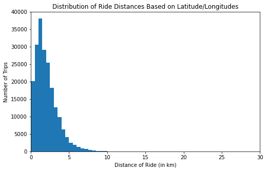

```python
binsize = 0.5
bins = np.arange(0, df_clean['dist_in_km'].max()+binsize, binsize)

plt.figure(figsize=[8, 5])
plt.hist(data = df_clean, x = 'dist_in_km', bins = bins)
plt.title('Distribution of Ride Distances Based on Latitude/Longitudes')
plt.xlabel('Distance of Ride (in km)')
plt.ylabel('Number of Trips')
plt.axis([0, 30, 0, 40000])
plt.show()
```

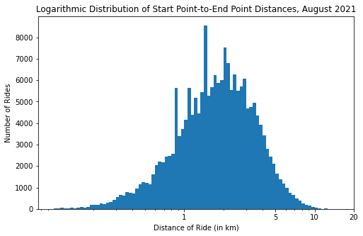

```python
log_binsize = 0.025
log_bins = 10 ** np.arange(-1, np.log10(df_clean['dist_in_km'].max()) + log_binsize, log_binsize)

plt.figure(figsize=[8, 5])
plt.hist(data = df_clean, x = 'dist_in_km', bins = log_bins)
plt.title('Logarithmic Distribution of Start Point-to-End Point Distances, August 2021')
plt.xlabel('Distance of Ride (in km)')
plt.ylabel('Number of Rides')
plt.xscale('log')
plt.xlim([0, 2e1])
plt.xticks([1, 5e0, 1e1, 2e1], ["1", "5", "10", "20"])

plt.show()
```

#### Let's take a look at estimated ride costs in August 2021.

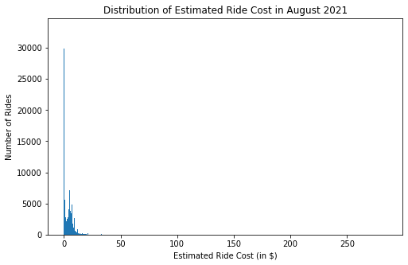

```python
binsize = 0.25
bins = np.arange(0, df_clean['est_ride_cost'].max()+binsize, binsize)

plt.figure(figsize=[8, 5])
plt.hist(data = df_clean, x = 'est_ride_cost', bins = bins)
plt.title('Distribution of Estimated Ride Cost in August 2021')
plt.xlabel('Estimated Ride Cost (in $)')
plt.ylabel('Number of Rides')
plt.show()
```

#### It looks like the cost for the majority of rides is close to \$0 -- probably because members don't always pay a per-ride fee -- but it's hard to tell. However, there is a long tail, which suggests that this data might be suited for a logarithmic scale.

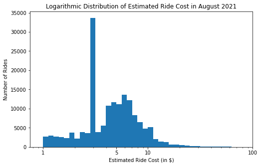

```python
log_binsize = 0.05
log_bins = 10 ** np.arange(0, np.log10(df_clean['est_ride_cost'].max()) + log_binsize, log_binsize)

plt.figure(figsize=[8, 5])
plt.hist(data = df_clean, x = 'est_ride_cost', bins = log_bins)
plt.title('Logarithmic Distribution of Estimated Ride Cost in August 2021')
plt.xscale('log')
plt.xlabel('Estimated Ride Cost (in $)')
plt.ylabel('Number of Rides')

plt.xlim([0, 1e2])
plt.xticks([1, 5e0, 1e1, 1e2], ["1", "5", "10", "100"])


plt.show()
```

#### When plotted on a log-scale, the distribution of estimated ride cost shows a large spike at around \$3, with another much smaller peak at around \\$6. The number of rides that cost more than \$6 drops pretty quickly.

### Discuss the distribution(s) of your variable(s) of interest. Were there any unusual points? Did you need to perform any transformations?

> The ride_duration, dist_in_kim and est_ride_cost variables took on a large range of values, so I looked at the data using a log transform. Under the transformation, the data looked roughly unimodal for ride_duration and dist_in_kim but not for est_ride_cost.

> There were more rides by casual riders than by members in August 2021.

### Of the features you investigated, were there any unusual distributions? Did you perform any operations on the data to tidy, adjust, or change the form of the data? If so, why did you do this?

> I wanted to know more about the time and day of the week for rides. To do this I had to manipulate the date/time data in the dataset. Once I converted the start_at and ended_at values to datetime objects and pulled out the start hour, end hour and day of the week for rides, I think it was unusual that more rides were on Sunday and Tuesday, even though the most common hours of the day for starting a ride was during what is generally considered to be rush hour. I also created values for ride duration (in minutes), distance between latitude/longitude points (in kilometers) and estimated cost for a ride.

> During my exploration I found outlier values (negative ride durations and ride durations of zero), which I dropped from the dataset. I also found rides where the end_lat values were null and the rides were days long. These are likely to be lost or stolen bikes and were dropped from the dataset as well. Also, I substituted the string "Unavailable" where the start or end station was null because I wanted to be able to chart the top 10 start and end stations and to get a better visual sense of how much data was missing.

## Bivariate Exploration

> I am going to examine pairwise relationships between features in the data.

#### First, let's use a heatmap to examine if there is any correlation between the numeric variables ride_duration, start_datehour, end_datehour, dist_in_km and est_ride_cost.

```python
numeric_vars = ["ride_duration", "start_datehour", "end_datehour", "dist_in_km", "est_ride_cost"]
categoric_vars = ["bike_type", "rider_type", "start_dayofweek"]
```

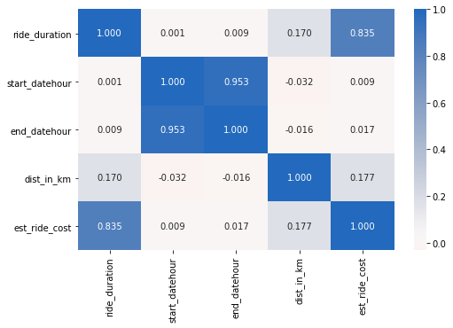

```python
plt.figure(figsize=[8,5])
sns.heatmap(df_clean[numeric_vars].corr(), annot = True, cmap='vlag_r', fmt = '.3f', center=0)
plt.show();
```

#### There is a strong correlation between start_datehour and end_datehour and between est_ride_cost and ride_duration, but otherwise, the numeric variables don't have any correlation. Let's use a PairGrid and a sample of the dataset to verify this.

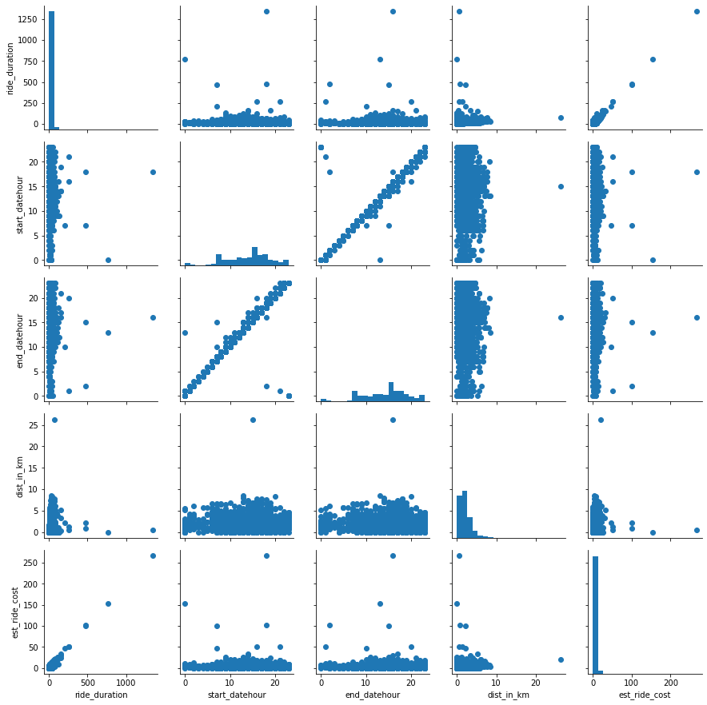

```python
#use sample size of 2000
df_clean_samp = df_clean.sample(n=2000, replace = False)

g = sns.PairGrid(data=df_clean_samp, vars = numeric_vars)
g = g.map_diag(plt.hist, bins = 20);
g.map_offdiag(plt.scatter);
```

#### As noted above, there is a strong correlation between start_datehour and end_datehour and between est_ride_cost and ride_duration, but otherwise, the numeric variables don't really correlate.

#### Let's plot a matrix of the numerical features ride_duration, dist_in_km and est_ride_cost against the categorical feature using PairGrid and boxplot. Given the size of the dataset, we'll work with a sample size of 2,000.

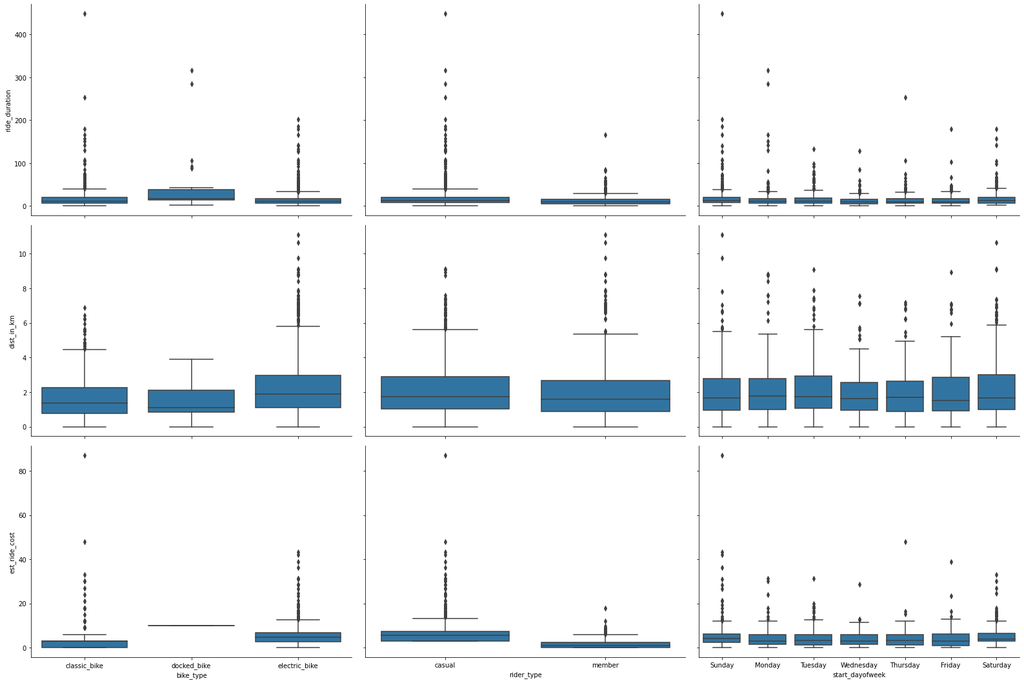

```python
#take a sample of the dataset, 2000 values
df_clean_samp = df_clean.sample(n=2000, replace = False)

def boxgrid(x, y, **kwargs):
    default_color = sns.color_palette()[0]
    sns.boxplot(x=x, y=y, color=default_color)

#plt.figure(figsize= [15,12])
g = sns.PairGrid(data=df_clean_samp, y_vars = ["ride_duration", "dist_in_km", "est_ride_cost"],
                 x_vars = categoric_vars, size = 5, height = 5, aspect = 1.5)
g.map(boxgrid)
plt.show();
```

#### Let's examine relationships between the three categorical features of bike type, rider type and start_dayofweek.

#### First, let's visualize the number of rides in August 2021 by day of the week and bike type.

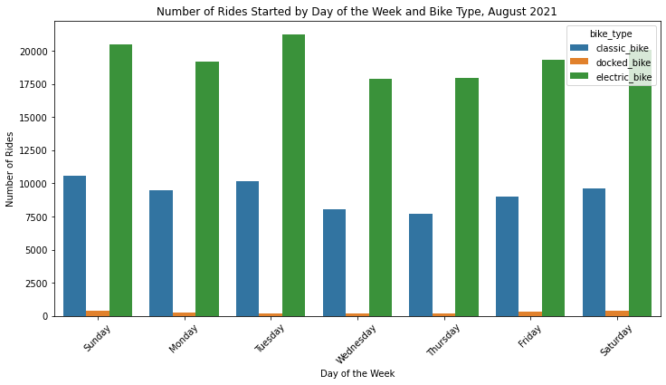

```python
fig, ax = plt.subplots(figsize=(12, 6))
chart= sns.countplot(x='start_dayofweek', data=df_clean, hue='bike_type', ax=ax)
chart.set_title("Number of Rides Started by Day of the Week and Bike Type, August 2021")
chart.set_xlabel("Day of the Week", fontsize = 10)
chart.set_ylabel("Number of Rides", fontsize = 10)
chart.set_xticklabels(chart.get_xticklabels(), rotation=45);
```

#### In August 2021, electric and classic bikes were ridden most often on Tuesdays, Sundays and Saturdays. Also, docked bikes were ridden most often on Sundays, Saturdays and Fridays.

#### Let's look at the number of rides in August 2021 by day of the week and rider type.

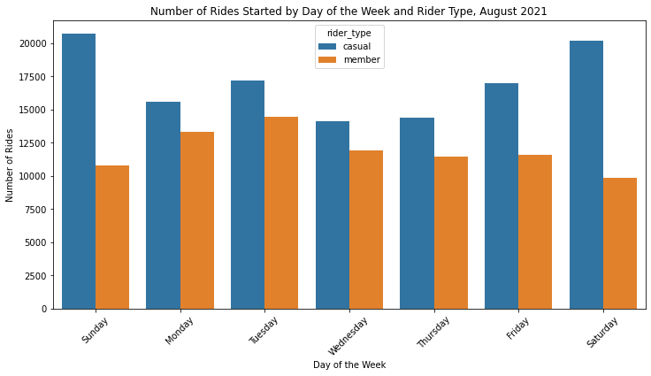

```python
fig, ax = plt.subplots(figsize=(12, 6))
chart = sns.countplot(x='start_dayofweek', data=df_clean, hue='rider_type', ax=ax)
chart.set_title("Number of Rides Started by Day of the Week and Rider Type, August 2021")
chart.set_xlabel("Day of the Week", fontsize = 10)
chart.set_ylabel("Number of Rides", fontsize = 10)
chart.set_xticklabels(chart.get_xticklabels(), rotation=45);
```

#### Let's examine how the start times for rides vary with the day of the week.

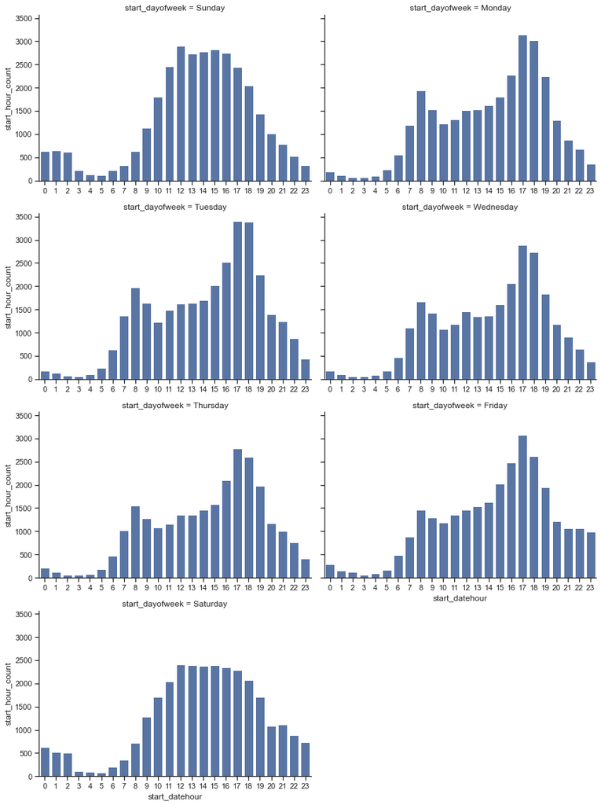

```python
# create facet grid with start_dayofweek and start_datehour to see how start hours for rides
#vary with the day of the week
sns.set(style="ticks", color_codes=True)

g = sns.FacetGrid(data=df_clean.groupby([
    'start_dayofweek',
    'start_datehour'
]).start_datehour.count().to_frame(name='start_hour_count').reset_index(),
                  col='start_dayofweek', col_wrap=2, height=4, aspect= 1.5)
for ax in g.axes.flatten():
    ax.tick_params(labelbottom=True)
# map barplot to each subplot
g.map(sns.barplot, 'start_datehour', 'start_hour_count');
```

#### In August 2021, there were distinctions in ride start times depending on whether it was a weekday or weekend. On the weekday plots there is a small peak at 8 a.m. and then a bigger peak at 5 p.m. with a dip in ridership between 8 a.m. and 3 p.m.; at around 3 p.m. the ridership starts to increase (rush hour begins). The weekend plots peak between noon and 4 p.m, with no dip like the weekday plots. The weekend plots also show more rides that start around midnight-2 a.m. than on the weekday plots.

#### Let's look at the number of rides by starting hour and rider type.

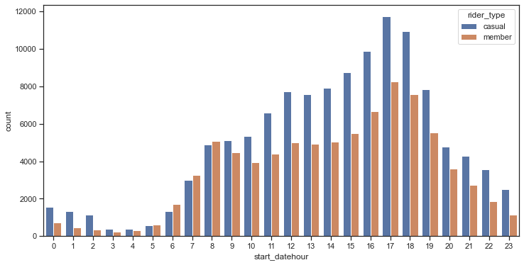

```python
fig, ax = plt.subplots(figsize=(12, 6))
sns.countplot(x='start_datehour', data=df_clean, hue='rider_type', ax=ax)
ax.set_xticklabels(ax.get_xticklabels(), rotation=0);
```

#### The ride patterns between casual riders and members by start hour are different. While both peak at 5 p.m. for ride starts, there is a small peak for members at 8 a.m., with a dip from 9-10 a.m. before slowly increasing. Even though overall more casual riders than members rode in August 2021, more members than casual riders started rides at 6, 7 and 8 a.m. By comparison, the casual riders' start hour pattern doesn't show a similar peak - dip - peak, but a relatively steady increase from about 4 a.m. until 5 p.m.

#### Let's look at the number of rides by starting hour and bike type.

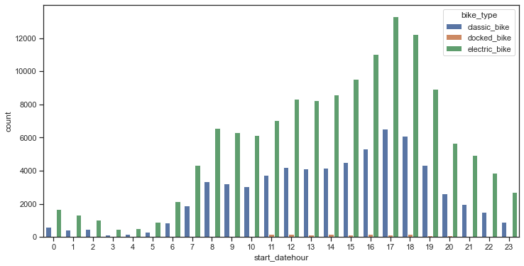

```python
fig, ax = plt.subplots(figsize=(12, 6))
sns.countplot(x='start_datehour', data=df_clean, hue='bike_type', ax=ax)
ax.set_xticklabels(ax.get_xticklabels(), rotation=0);
```

#### The start hour for rides peaks at 5 p.m. for both electric and classic bikes, and drops after 5 p.m for both types of bikes. Interestingly, the start hours for docked bikes appears to be primarily between 11 a.m. and 7 p.m.

#### Let's examine the number of rides started each day in August 2021.

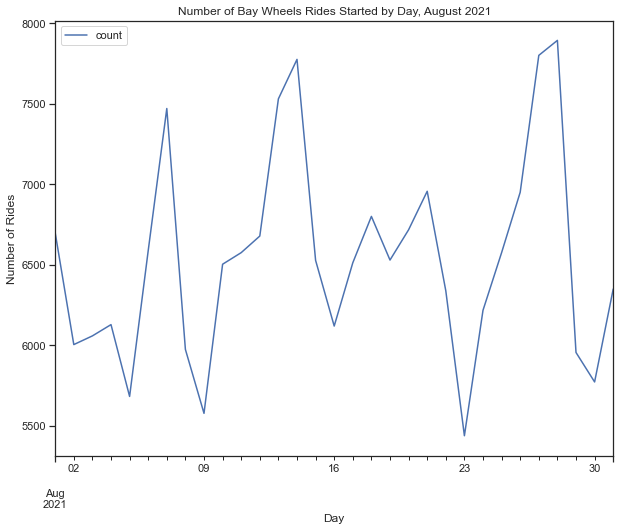

```python
test = df_clean["started_at"].groupby(df_clean["started_at"].dt.floor('d')).size().reset_index(name='count')
test.plot(x='started_at',y='count', kind="line")
plt.title("Number of Bay Wheels Rides Started by Day, August 2021")
plt.xlabel('Day')
plt.ylabel('Number of Rides')
plt.show();
```

#### This line chart shows that in August 2021, the number of rides per day followed a rough pattern that tended to dip on Mondays and peak on Saturdays.

#### Let's see how the number of rides per day is different if we look at rides by members and by casual riders.

```python
test1 = df_clean["started_at"].groupby([df_clean["started_at"].dt.floor('d'), df_clean["rider_type"]]).size().reset_index(name='count')
test1["date"] = test1["started_at"].dt.strftime('%a %d')
```

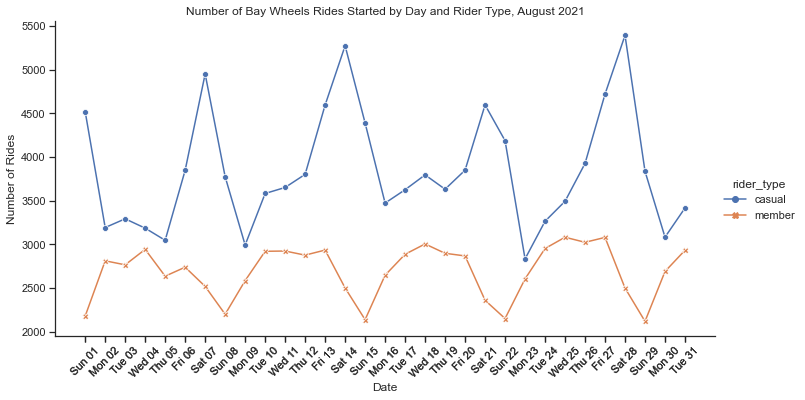

```python
#create a line chart with showing the number of rides started per day by rider type
ax=sns.relplot(x="date", y="count",
            data=test1, kind="line",
            ci=None, style="rider_type",
            hue="rider_type",
            markers=True,
            dashes=False, height=5, aspect = 2)
plt.title("Number of Bay Wheels Rides Started by Day and Rider Type, August 2021")
plt.xlabel('Date')
plt.ylabel('Number of Rides')
plt.xticks(test1["date"], rotation=45);
```

#### Let's see if the daily pattern is different if we create a line chart showing the number of rides per day in August by bike type.

```python
#create a dataframe that contains the day of the week and date from started_at and is grouped by bike type
test2 = df_clean["started_at"].groupby([df_clean["started_at"].dt.floor('d'), df_clean["bike_type"]]).size().reset_index(name='count')

test2["date"] = test2["started_at"].dt.strftime('%a %d')
```

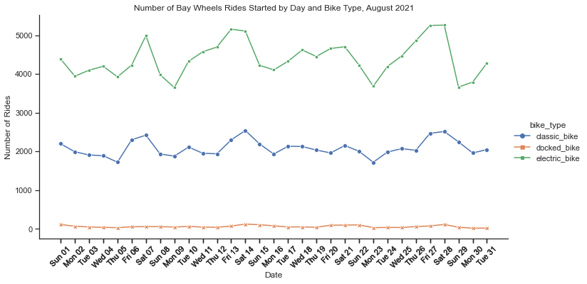

```python
#create a line chart with showing the number of rides per day by bike type
ax=sns.relplot(x="date", y="count",
            data=test2, kind="line",
            ci=None, style="bike_type",
            hue="bike_type",
            markers=True,
            dashes=False, height=5, aspect = 2)
plt.title("Number of Bay Wheels Rides Started by Day and Bike Type, August 2021")
plt.xlabel('Date')
plt.ylabel('Number of Rides')
plt.xticks(test2["date"], rotation=45);
```

#### More electric bikes are ridden than classic bikes on a daily basis, though the peaks on Fridays and Saturdays are similar.

#### Let's create a line chart showing the number of rides per day in August 2021 by membership type (casual riders vs. members).

```python
#group data by start day and rider type
test1 = df_clean["started_at"].groupby([df_clean["started_at"].dt.floor('d'), df_clean["rider_type"]]).size().reset_index(name='count')
```

```python
#convert date to day of the week and day of month format
test1["date"] = test1["started_at"].dt.strftime('%a %d')
```

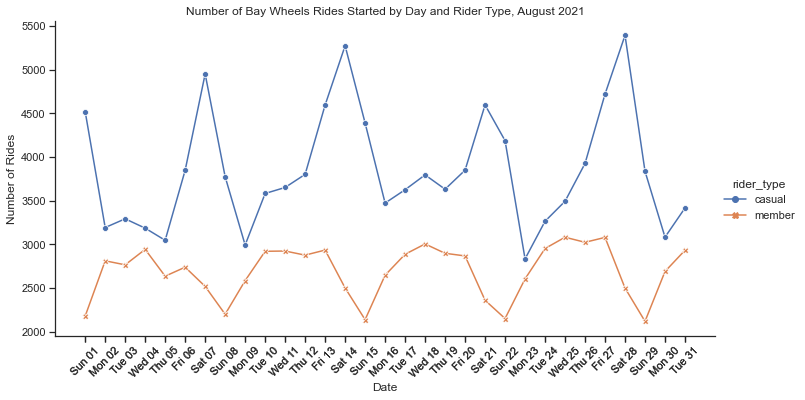

```python
#create a line chart with showing the number of rides per day by rider type
ax=sns.relplot(x="date", y="count",
            data=test1, kind="line",
            ci=None, style="rider_type",
            hue="rider_type",
            markers=True,
            dashes=False, height=5, aspect = 2)
plt.title("Number of Bay Wheels Rides Started by Day and Rider Type, August 2021")
plt.xlabel('Date')
plt.ylabel('Number of Rides')
plt.xticks(test1["date"], rotation=45);
```

#### The ride patterns are different for casual riders vs. members. The number of rides by casual riders tend to peak on Saturdays and appear to be lowest on Mondays. By comparison, members tend to ride during the weekday, with ridership dropping on Saturdays and dropping to their lowest on Sundays. The ride pattern for members from Sunday-Saturday are similar throughout August 2021.

#### Let's create a line chart showing the number of rides started per day in August 2021 by bike type.

```python
#first create a dataframe that groups the number of rides per day by bike type
test2 = df_clean["started_at"].groupby([df_clean["started_at"].dt.floor('d'), df_clean["bike_type"]]).size().reset_index(name='count')
```

```python
#convert date to day of the week and day of month format
test2["date"] = test2["started_at"].dt.strftime('%a %d')
```

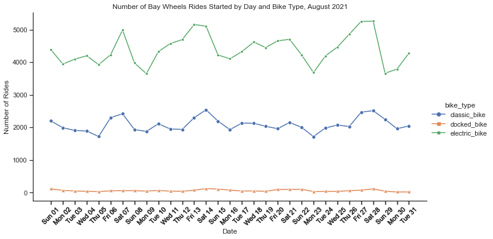

```python
#create a line chart with showing the number of rides per day by bike type
ax=sns.relplot(x="date", y="count",
            data=test2, kind="line",
            ci=None, style="bike_type",
            hue="bike_type",
            markers=True,
            dashes=False, height=5, aspect = 2)
plt.title("Number of Bay Wheels Rides Started by Day and Bike Type, August 2021")
plt.xlabel('Date')
plt.ylabel('Number of Rides')
plt.xticks(test2["date"], rotation=45);
```

### Did you observe any interesting relationships between the other features (not the main feature(s) of interest)?

> That more members and casual riders rode electric bikes instead of classic bikes and that the median ride duration in minutes (except for a few outliers) for both electric and classic bikes are similar. Also, on a daily basis, the ride patterns are different for casual riders vs. members. The number of rides by casual riders tend to peak on Saturdays and appear to be lowest on Mondays. By comparison, members tend to ride during the weekday, with ridership dropping on Saturdays and dropping to their lowest on Sundays.

## Multivariate Exploration

> In this part of the analysis, I want to look at how the two categorical variables, bike_type and rider_type, play into the relationship with the mean of ride_duration, est_ride_cost and dist_in_km by day_of_the_week.

#### Let's look at the relationship between mean ride duration (in minutes) and day of the week by bike type.

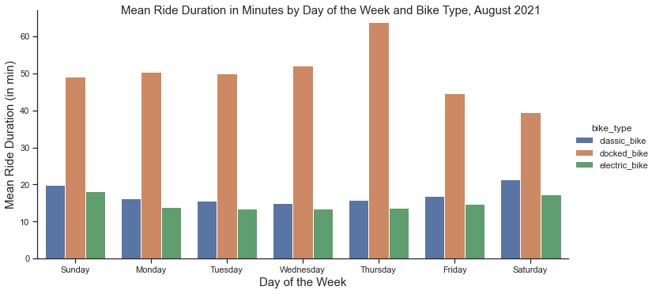

```python
chart = sns.catplot(x="start_dayofweek", y = "ride_duration", kind = "bar", hue = "bike_type", data=df_clean, height=5, aspect=2, ci=None);
chart.fig.suptitle("Mean Ride Duration in Minutes by Day of the Week and Bike Type, August 2021", fontsize=15)
chart.set_xlabels('Day of the Week', fontsize=15)
chart.set_ylabels('Mean Ride Duration (in min)', fontsize=15)
plt.show();
```

#### Let's look at the relationship between mean ride duration (in minutes) and day of the week by rider type.

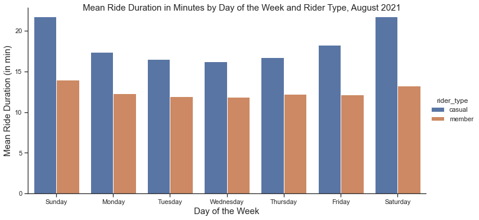

```python
chart = sns.catplot(x="start_dayofweek", y = "ride_duration", kind="bar", hue = "rider_type", data=df_clean, height=5, aspect=2, ci=None);
chart.fig.suptitle("Mean Ride Duration in Minutes by Day of the Week and Rider Type, August 2021", fontsize=15)
chart.set_xlabels('Day of the Week', fontsize=15)
chart.set_ylabels('Mean Ride Duration (in min)', fontsize=15)
plt.show();
```

#### The average (mean) ride duration by casual riders is greater than the average (mean) ride duration of member riders, both on weekdays and weekends. Mean ride duration for member rides is less than 15 minutes.

#### Let's look at the relationship between mean ride duration (in minutes) and day of the week for members and casual riders, by bike type.

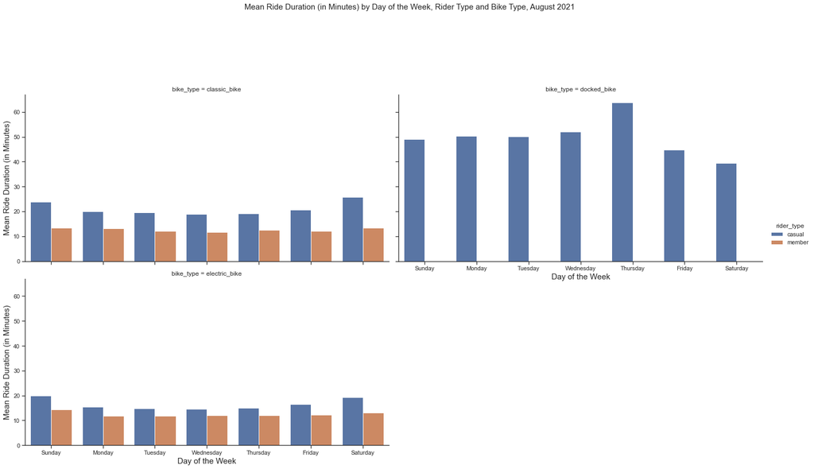

```python
chart = sns.catplot(x="start_dayofweek", y="ride_duration", hue="rider_type", kind="bar",
                col="bike_type", col_wrap = 2, data=df_clean, height=5, aspect=2, ci=None);
chart.fig.suptitle("Mean Ride Duration (in Minutes) by Day of the Week, Rider Type and Bike Type, August 2021", fontsize=15, y= 1.2);
chart.set_xlabels('Day of the Week', fontsize=15)
chart.set_ylabels('Mean Ride Duration (in Minutes)', fontsize=15)
plt.show();
```

#### Let's look at the relationship between mean ride duration (in minutes) and day of the week for electric, classic and docked bikes, by rider type.

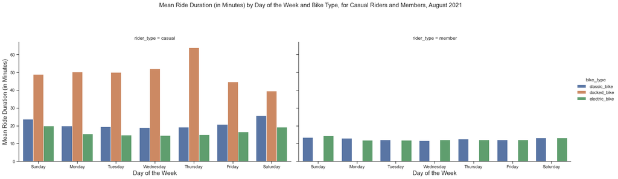

```python
chart = sns.catplot(x="start_dayofweek", y="ride_duration", hue="bike_type", kind="bar",
                col="rider_type", data=df_clean, height=5, aspect=2, ci=None);
chart.fig.suptitle("Mean Ride Duration (in Minutes) by Day of the Week and Bike Type, for Casual Riders and Members, August 2021", fontsize=15, y= 1.2);
chart.set_xlabels('Day of the Week', fontsize=15)
chart.set_ylabels('Mean Ride Duration (in Minutes)', fontsize=15)
plt.show();
```

#### Let's look at mean estimated ride cost (in \$) by day of the week and rider type.

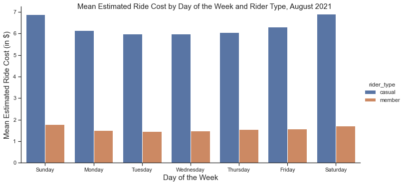

```python
chart = sns.catplot(x="start_dayofweek", y = "est_ride_cost", kind="bar", hue = "rider_type", data=df_clean, height=5, aspect=2, ci=None)
chart.fig.suptitle("Mean Estimated Ride Cost by Day of the Week and Rider Type, August 2021", fontsize=15)
chart.set_xlabels('Day of the Week', fontsize=15)
chart.set_ylabels('Mean Estimated Ride Cost (in $)', fontsize=15)
plt.show();
```

#### Let's look at mean estimated ride cost (in \$) by day of the week and bike type.

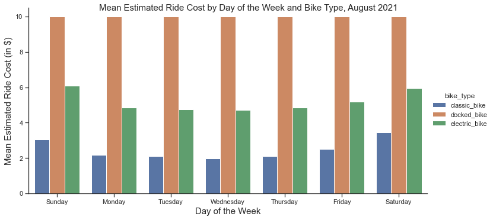

```python
chart = sns.catplot(x="start_dayofweek", y = "est_ride_cost", kind="bar", hue = "bike_type", data=df_clean, height=5, aspect=2, ci=None)
chart.fig.suptitle("Mean Estimated Ride Cost by Day of the Week and Bike Type, August 2021", fontsize=15)
chart.set_xlabels('Day of the Week', fontsize=15)
chart.set_ylabels('Mean Estimated Ride Cost (in $)', fontsize=15)
plt.show();
```

#### Earlier in the analysis we assumed that docked bikes were simply classic bikes ridden by casual riders on an all-day pass, which costs \$10. The mean estimated ride cost is highest on Sunday and Saturday for both electric bikes and classic bikes. This is probably reflects members riding during the weekday, and member rides are "free" (i.e., covered by the membership fee) for the first 45 minutes of a ride.

#### Let's look at the relationship between mean estimated ride cost (in dollars) and day of the week for classic, electric and docked bikes, by rider type.

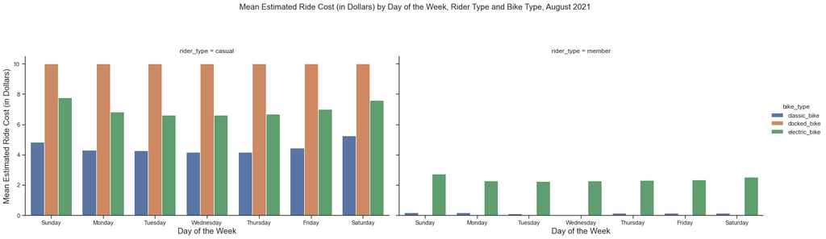

```python
chart = sns.catplot(x="start_dayofweek", y="est_ride_cost", hue="bike_type", kind="bar",
                col="rider_type", data=df_clean, height=5, aspect=2, ci=None);
chart.fig.suptitle("Mean Estimated Ride Cost (in Dollars) by Day of the Week, Rider Type and Bike Type, August 2021", fontsize=15, y= 1.2);
chart.set_xlabels('Day of the Week', fontsize=15)
chart.set_ylabels('Mean Estimated Ride Cost (in Dollars)', fontsize=15)
plt.show();
```

#### The mean estimated ride cost is higher for casual riders than for members both on classic and electric bikes, and it is higher on Saturdays and Sundays. The mean estimated ride cost for member rides on classic bikes is low because most of the member rides on classic bikes are covered by the membership fee (where the first 45 minutes are free), but mean estimated cost ride for electric bikes is between \$2-$3 and appears to be higher on Sundays and Saturdays as well.

#### Let's look at the mean estimated ride distance (as it is measured from start point to end point, not actual route) by day of the week and by bike type.

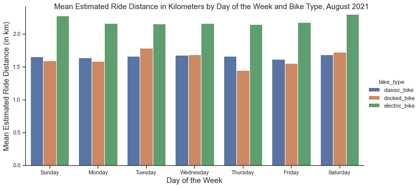

```python
chart = sns.catplot(x="start_dayofweek", y = "dist_in_km", kind = "bar", hue = "bike_type", data=df_clean, height=5, aspect=2, ci=None);
chart.fig.suptitle("Mean Estimated Ride Distance in Kilometers by Day of the Week and Bike Type, August 2021", fontsize=15)
chart.set_xlabels('Day of the Week', fontsize=15)
chart.set_ylabels('Mean Estimated Ride Distance (in km)', fontsize=15)
plt.show();
```

#### The mean ride distance from start point to end point is farthest (slightly over a mile) on electric bikes and in particular on Saturdays and Sundays.

#### Let's look at the mean ride distance (as it is measured from start point to end point, not actual route) by day of the week and by rider type.

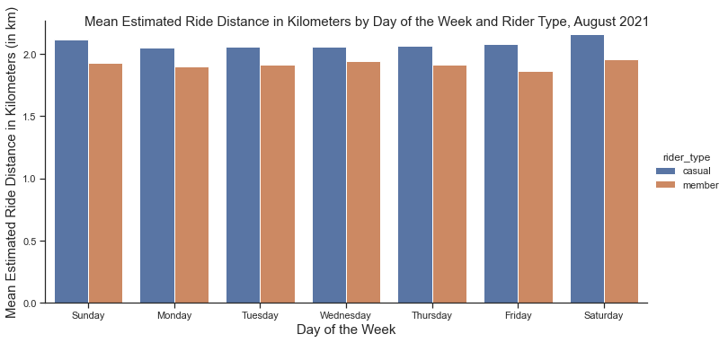

```python
chart = sns.catplot(x="start_dayofweek", y = "dist_in_km", kind="bar", hue = "rider_type", data=df_clean, height=5, aspect=2, ci=None);
chart.fig.suptitle("Mean Estimated Ride Distance in Kilometers by Day of the Week and Rider Type, August 2021", fontsize=15)
chart.set_xlabels('Day of the Week', fontsize=15)
chart.set_ylabels('Mean Estimated Ride Distance in Kilometers (in km)', fontsize=15)
plt.show();
```

#### The mean ride distance is farthest (slightly over a mile) for casual riders and in particular on Saturdays and Sundays. Mean ride distance by members is slightly lower than by casual riders.

#### Let's look at the mean estimated ride distance by day of the week and bike type, for casual riders vs. members.

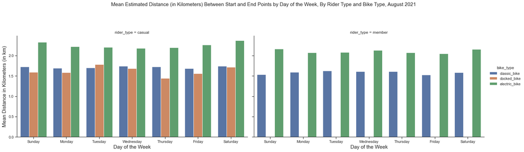

```python
chart = sns.catplot(x="start_dayofweek", y="dist_in_km", hue="bike_type", kind="bar",
                col="rider_type", data=df_clean, height=5, aspect=2, ci=None)
chart.fig.suptitle("Mean Estimated Distance (in Kilometers) Between Start and End Points by Day of the Week, By Rider Type and Bike Type, August 2021", fontsize=15, y= 1.2);
chart.set_xlabels('Day of the Week', fontsize=15)
chart.set_ylabels('Mean Distance in Kilometers (in km)', fontsize=15)
plt.show();
```

#### The mean estimated ride distance (measuring from start point to end point, not actual route) is longer for both casual riders and members on electric bikes than on classic bikes. Interestingly, the mean estimated ride distance on docked bikes is shorter than for electric bikes, even though the mean ride duration is longer on docked bikes.

### Talk about some of the relationships you observed in this part of the investigation. Were there features that strengthened each other in terms of looking at your feature(s) of interest?

> Overall, Bay Wheels are ridden for relatively short "final mile" trips that average a little more than a mile and take 15-20 minutes. More rides were by casual riders on electric bikes and they tended to ride on weekends. Members tended to ride on weekdays and not on weekends, which suggests that members ride Bay Wheels are part of a regular commute to and from downtown SF. Member rides during the weekday showed two peaks, one during morning rush hour and one during late afternoon/early evening rush hour; casual rides during the weekday showed one peak during late afternoon/early evening rush hour(5 p.m.). And even though it is a point-to-point estimate, the mean estimated ride distance was farther for both casual riders and members on electric bikes than on classic bikes, which makes sense if you need to get somewhere without sweating.

### Were there any interesting or surprising interactions between features?

> Given that we are in a pandemic and people are still working remotely, I am not surprised that overall, member ridership is lower than casual ridership. I was surprised, however, that casual ridership peaks on the weekends. Also, I was surprised that the mean ride duration for members were similar on both weekdays and weekends, even though members take fewer rides on the weekends. Finally, I was surprised that the mean estimated ride distance on docked bikes was shorter than for electric bikes, even though the mean ride duration is longer for docked bikes.